# Anomaly Detection and Time-Series Analysis for Supplier Service Volumes and Medicare Payments

## Introduction

This notebook explores the temporal patterns and fluctuations in supplier service volumes and Medicare payments, with a focus on identifying inefficiencies or anomalies in the data. The goal is to use anomaly detection models to uncover periods of unusual behavior that could suggest inefficiencies or potential fraud. The analysis employs Isolation Forest and Local Outlier Factor (LOF) models, which are effective for detecting anomalies in high-dimensional datasets.

## Unsupervised Classification Overview

Unsupervised classification, unlike supervised classification, does not rely on labeled data to learn the patterns or relationships in the data. Instead, it identifies inherent structures within the data without predefined categories.

## Feature Selection

- **`Tot_Suplrs`**: Total number of suppliers
- **`Tot_Suplr_Benes`**: Total number of beneficiaries
- **`Tot_Suplr_Srvcs`**: Total number of services provided by suppliers
- **`Avg_Suplr_Sbmtd_Chrg`**: Average supplier submitted charges
- **`Avg_Suplr_Mdcr_Alowd_Amt`**: Average Medicare allowed amount
- **`Avg_Suplr_Mdcr_Pymt_Amt`**: Average Medicare payment amount

Using all six features, identified through PCA, ensures that anomalies in any variable, even those not directly tied to the research question, are detected and removed before proceeding to ARIMA modeling. This provides a cleaner dataset for time-series analysis.

For the research question analysis, we focus specifically on **supplier service volumes** (`Tot_Suplr_Srvcs`) and **Medicare payment amounts** (`Avg_Suplr_Mdcr_Pymt_Amt`):

- These two variables are directly relevant to identifying inefficiencies or potential fraud in service volumes and payments.
- The other features provide context but are excluded during the focused research question analysis to streamline the insights.

By narrowing the scope for the research question, we maintain clarity while leveraging a robust anomaly detection approach for preprocessing.

## Models Used

- **Isolation Forest**: The Isolation Forest algorithm identifies anomalies by isolating data points that deviate from the majority. It isolates outliers by constructing multiple trees where those anomalies are easier to isolate due to their distance from the majority of the data points.
- **Local Outlier Factor (LOF)**: LOF detects anomalies by measuring the local density deviation of a data point with respect to its neighbors. Points with significantly lower density compared to their neighbors are flagged as anomalies. LOF is more sensitive to local changes and can detect anomalies in regions where the overall distribution of data is uneven.

## Comparison and Selection

The winner between Isolation Forest and LOF will be selected based on their ability to identify meaningful anomalies in the supplier behavior data. The selected model will be used to detect outliers and remove them from the dataset, ensuring cleaner data for subsequent analysis. By removing these outliers, we can ensure that the models used in the following analysis are more robust and less likely to be skewed by extreme values.

## Modeling Steps

1. **Train both models**: Fit both Isolation Forest and LOF models to the data using all six features.
2. **Evaluate performance**: Compare their ability to identify anomalies based on the outlier rates and their impact on the overall dataset.
3. **Select the best model**: Choose the model that performs better in terms of outlier detection and anomaly identification.
4. **Remove detected anomalies**: Use the selected model to flag and remove the anomalies from the dataset for cleaner, more reliable analysis.
5. **Focus on relevant features for research question**: Analyze temporal patterns and anomalies in `Tot_Suplr_Srvcs` and `Avg_Suplr_Mdcr_Pymt_Amt` to address the research question.

By applying these techniques, we ensure that only meaningful data is used for further modeling, improving the accuracy and interpretability of the subsequent analyses.

## Research Question

**RQ1: How do supplier service volumes and Medicare payments fluctuate over time, and which specific periods exhibit inefficiencies or signs of potential fraud requiring targeted interventions?**

The aim is to explore how anomalies in service volumes and Medicare payments can indicate periods of inefficiency, potential fraud, or other factors that might require targeted intervention.

### Goals:

- Identify temporal patterns in service volumes and Medicare payments.
- Detect outliers in the data that may indicate inefficiencies or anomalies.
- Understand how anomalies evolve over time and across different regions.
- Use anomaly detection models (Isolation Forest and LOF) to remove outliers and clean the data for further analysis.

## Time-Series Split Cross-Validation

Since the data is temporal, we apply TimeSeriesSplit to ensure that each model is trained on past data and tested on future data, avoiding data leakage. This method allows us to better assess how the models perform on unseen data, which is crucial for ensuring the robustness and reliability of the analysis.

## Model Comparison

- **Isolation Forest vs. LOF**: By comparing the two models, we aim to identify which is better suited for anomaly detection in this context. The best-performing model will be used to flag anomalies and clean the dataset.
- **Evaluation**: Metrics like the outlier rate (percentage of anomalies detected) and their impact on model performance will be evaluated.

## Conclusion

This notebook aims to identify temporal anomalies in supplier service volumes and Medicare payments, helping to uncover inefficiencies, potential fraud, or areas that need targeted intervention. By comparing Isolation Forest and LOF models, the notebook ensures that only the best model is used for detecting and removing anomalies from the data, thereby improving the accuracy of subsequent analyses.

With the selected anomaly detection model, we will proceed to explore the relationships between service volumes and Medicare payments, ultimately contributing to a deeper understanding of inefficiencies in the Medicare DMEPOS system.

```python
import os

# Set the working directory to the folder
os.chdir('/Users/rozani/Desktop/capstone')
```

```python
# Suppress warnings during execution
import warnings
warnings.filterwarnings("ignore")

# Importing essential libraries for data handling, modeling, and visualization
import numpy as np
import pandas as pd
import seaborn as sns
import matplotlib.pyplot as plt

# Anomaly detection and model evaluation tools
from sklearn.ensemble import IsolationForest
from sklearn.neighbors import LocalOutlierFactor
from sklearn.preprocessing import StandardScaler
from sklearn.model_selection import TimeSeriesSplit
```

```python
# Load the training data
train_data = pd.read_csv('combined_data.csv')
print(train_data.columns)
```

```
Index(['Rfrg_Prvdr_Geo_Lvl', 'Rfrg_Prvdr_Geo_Cd', 'Rfrg_Prvdr_Geo_Desc',
       'RBCS_Lvl', 'RBCS_Id', 'RBCS_Desc', 'HCPCS_Cd', 'HCPCS_Desc',
       'Suplr_Rentl_Ind', 'Tot_Rfrg_Prvdrs', 'Tot_Suplrs', 'Tot_Suplr_Benes',
       'Tot_Suplr_Clms', 'Tot_Suplr_Srvcs', 'Avg_Suplr_Sbmtd_Chrg',
       'Avg_Suplr_Mdcr_Alowd_Amt', 'Avg_Suplr_Mdcr_Pymt_Amt',
       'Avg_Suplr_Mdcr_Stdzd_Amt', 'Year', 'high_charges',
       'low_service_volumes', 'is_underserved', 'underserved_level'],
      dtype='object')
```

### Time-Series Cross-Validation for Anomaly Detection

```python
# Define features for scaling and anomaly detection
features = ['Tot_Suplrs', 'Tot_Suplr_Benes', 'Tot_Suplr_Srvcs',
            'Avg_Suplr_Sbmtd_Chrg', 'Avg_Suplr_Mdcr_Alowd_Amt',
            'Avg_Suplr_Mdcr_Pymt_Amt']
# Scale the features in training and test datasets
scaler = StandardScaler()
X_train = scaler.fit_transform(train_data[features])


# Set up time-series cross-validation
tscv = TimeSeriesSplit(n_splits=5)

# Initialize models
isf_model = IsolationForest(contamination=0.05, random_state=42)
lof_model = LocalOutlierFactor(n_neighbors=20, contamination=0.05, novelty=True) # novelty=True to for detecting anomalies on unseen data

# Time-Series Cross-Validation with Fold Results
results = []

for fold, (train_idx, test_idx) in enumerate(tscv.split(X_train), 1):
    # Split training data into fold training and testing sets
    X_fold_train, X_fold_test = X_train[train_idx], X_train[test_idx]

    # Train Isolation Forest and calculate anomaly rate
    isf_model.fit(X_fold_train)
    isf_preds = isf_model.predict(X_fold_test)
    isf_outlier_rate = (isf_preds == -1).mean()

    # Train Local Outlier Factor and calculate anomaly rate
    lof_model.fit(X_fold_train)
    lof_preds = lof_model.predict(X_fold_test)
    lof_outlier_rate = (lof_preds == -1).mean()

    # Track shared anomalies
    shared_anomalies_train = sum((isf_preds == -1) & (lof_preds == -1))

    # Store results
    results.append({
        'Fold': fold,
        'ISF Outlier Rate': isf_outlier_rate,
        'LOF Outlier Rate': lof_outlier_rate,
        'Shared Anomalies': shared_anomalies_train
    })

# Create DataFrame for results
results_df = pd.DataFrame(results)
print("Fold-Wise Anomaly Rates and Shared Anomalies:")
print(results_df)
```

```
Fold-Wise Anomaly Rates and Shared Anomalies:
   Fold  ISF Outlier Rate  LOF Outlier Rate  Shared Anomalies
0     1          0.056716          0.059644               876
1     2          0.054560          0.074591               799
2     3          0.050635          0.066497               677
3     4          0.064321          0.072211               893
4     5          0.048826          0.070422               659
```

## Fold-Wise Anomaly Rates and Shared Anomalies

The table below summarizes the anomaly detection results for each fold during time-series cross-validation. It highlights the outlier rates identified by **Isolation Forest (ISF)** and **Local Outlier Factor (LOF)** models, along with the count of anomalies shared between the two models.

| Fold | ISF Outlier Rate | LOF Outlier Rate | Shared Anomalies |
| --- | --- | --- | --- |
| 1 | 0.056716 | 0.059644 | 876 |
| 2 | 0.054560 | 0.074591 | 799 |
| 3 | 0.050635 | 0.066497 | 677 |
| 4 | 0.064321 | 0.072211 | 893 |
| 5 | 0.048826 | 0.070422 | 659 |

### Observations:

1. **ISF and LOF Outlier Rates**:
   - The outlier rates for Isolation Forest (ISF) and Local Outlier Factor (LOF) are fairly close, indicating alignment in their detection.
   - LOF typically detects slightly higher outlier rates compared to ISF.
2. **Shared Anomalies**:
   - The count of shared anomalies varies across folds, ranging from 659 to 893.
   - Shared anomalies indicate agreement between the two models, reinforcing their robustness.
3. **Consistency**:
   - The results show consistent outlier rates across folds, supporting the reliability of the models for anomaly detection.

These results provide insights into how the models perform across temporal splits, helping identify anomalous behaviors over time.

### Calculate Average Rates and Visualize Results

```
Average Outlier Rate - Isolation Forest: 0.055011692933401114
Average Outlier Rate - Local Outlier Factor: 0.06867310625317743
```

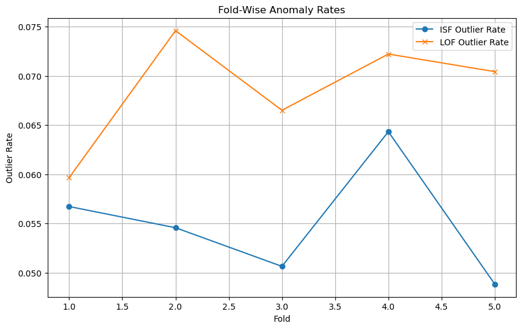

```python
# Average rates for comparison
avg_isf_rate = results_df['ISF Outlier Rate'].mean()
avg_lof_rate = results_df['LOF Outlier Rate'].mean()
print(f"\nAverage Outlier Rate - Isolation Forest: {avg_isf_rate}")
print(f"Average Outlier Rate - Local Outlier Factor: {avg_lof_rate}")

# Visualize fold-wise anomaly rates
plt.figure(figsize=(10, 6))
plt.plot(results_df['Fold'], results_df['ISF Outlier Rate'], label='ISF Outlier Rate', marker='o')
plt.plot(results_df['Fold'], results_df['LOF Outlier Rate'], label='LOF Outlier Rate', marker='x')
plt.title('Fold-Wise Anomaly Rates')
plt.xlabel('Fold')
plt.ylabel('Outlier Rate')
plt.legend()
plt.grid(True)
plt.show()
```

## Feature Contributions to Anomalies Detected by ISF and LOF

```
Total anomalies detected by ISF: 14753
Total anomalies detected by LOF: 12946
Shared anomalies: 1809
```

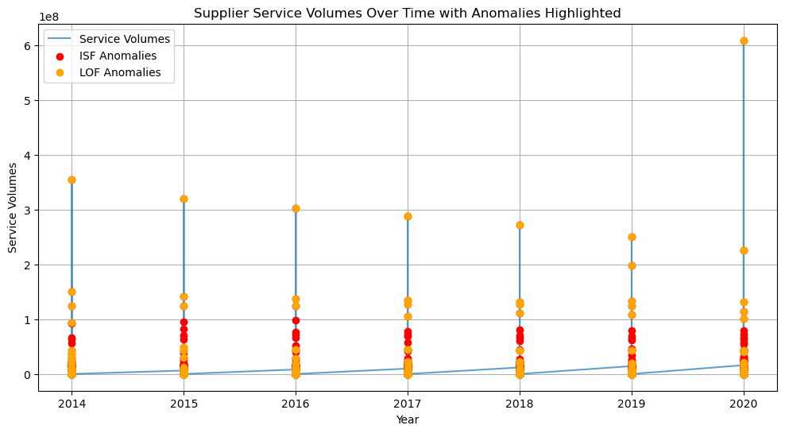

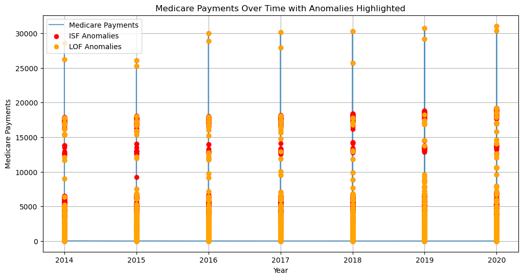

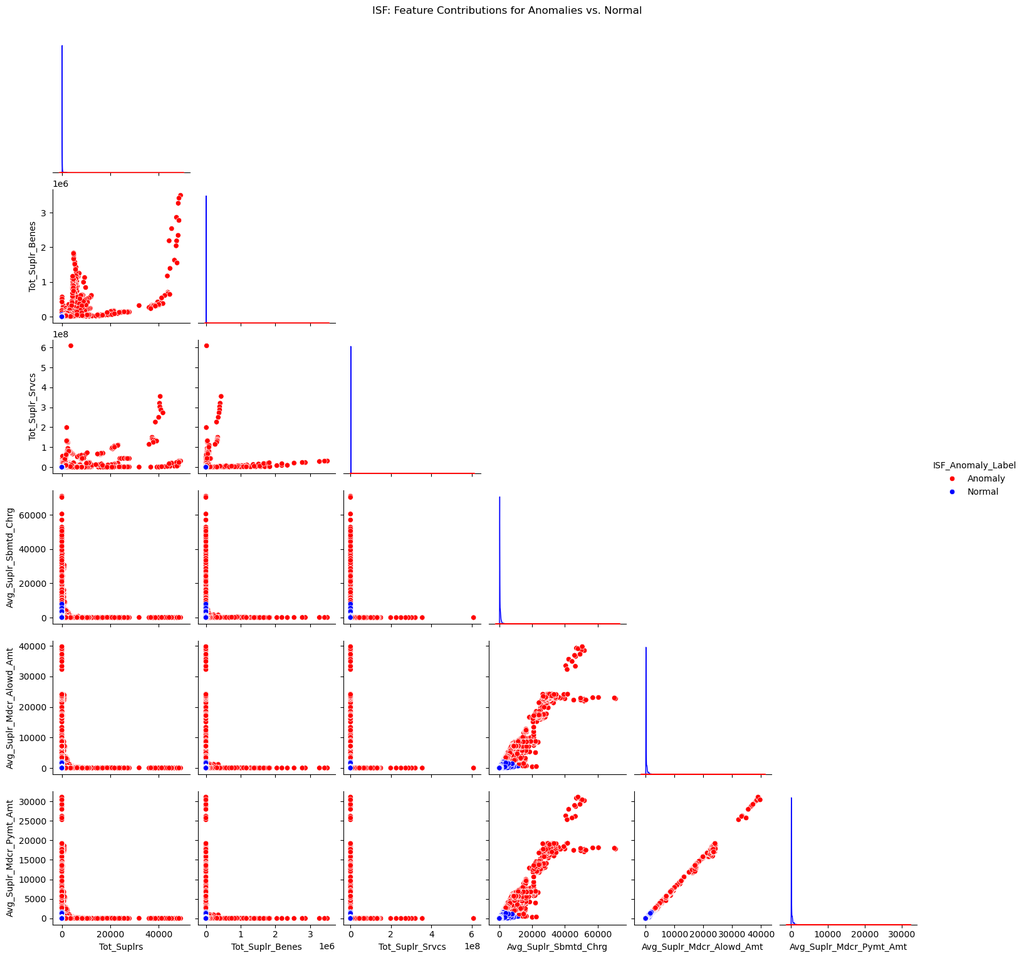

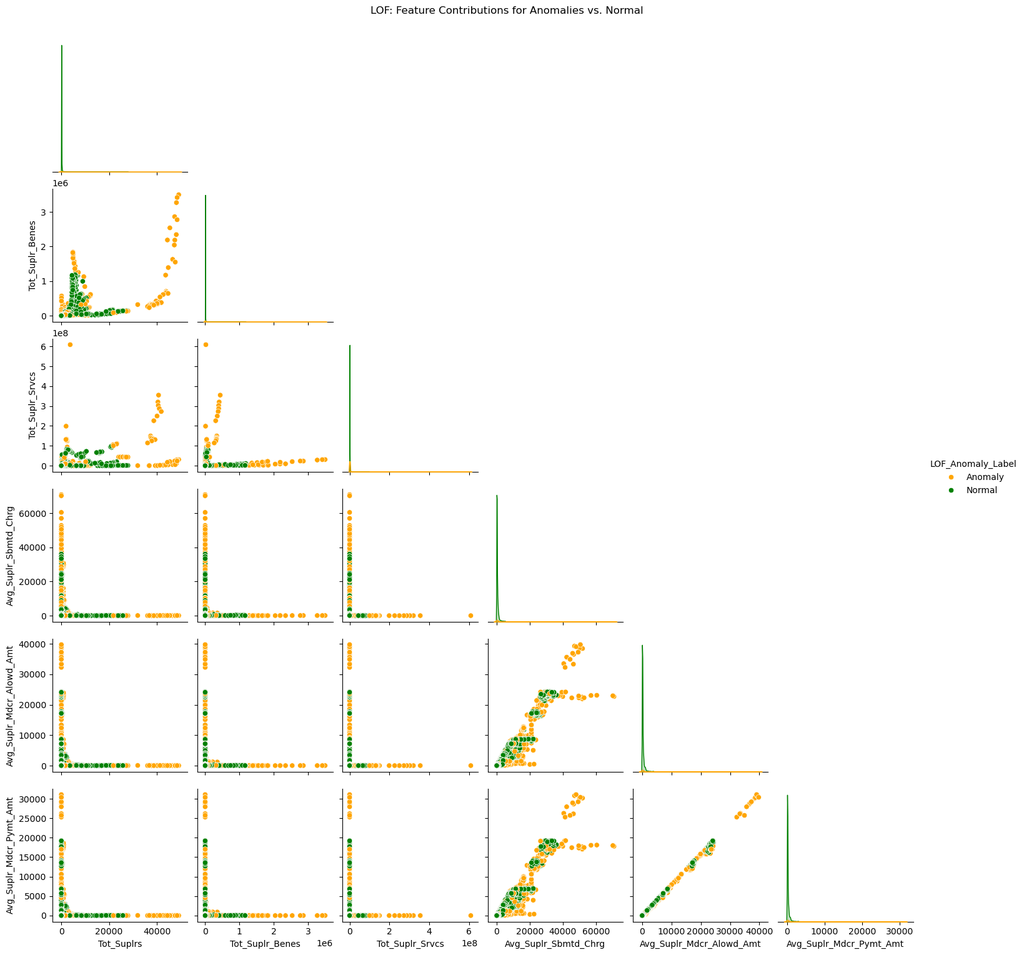

```python
# Fit models on the entire dataset for anomaly detection
isf_model.fit(X_train)
train_data['ISF_Anomaly'] = isf_model.predict(X_train)  # -1 for anomalies, 1 for normal

lof_model.fit(X_train)
train_data['LOF_Anomaly'] = lof_model.predict(X_train)  # -1 for anomalies, 1 for normal

# Compare anomalies detected by both models
isf_anomalies = train_data[train_data['ISF_Anomaly'] == -1]
lof_anomalies = train_data[train_data['LOF_Anomaly'] == -1]
shared_anomalies = isf_anomalies.index.intersection(lof_anomalies.index)

# Print summary of anomalies
print(f"Total anomalies detected by ISF: {len(isf_anomalies)}")
print(f"Total anomalies detected by LOF: {len(lof_anomalies)}")
print(f"Shared anomalies: {len(shared_anomalies)}")

# Visualize anomalies in service volumes
plt.figure(figsize=(12, 6))
plt.plot(train_data['Year'], train_data['Tot_Suplr_Srvcs'], label='Service Volumes', alpha=0.7)
plt.scatter(isf_anomalies['Year'], isf_anomalies['Tot_Suplr_Srvcs'], color='red', label='ISF Anomalies', zorder=3)
plt.scatter(lof_anomalies['Year'], lof_anomalies['Tot_Suplr_Srvcs'], color='orange', label='LOF Anomalies', zorder=3)
plt.title('Supplier Service Volumes Over Time with Anomalies Highlighted')
plt.xlabel('Year')
plt.ylabel('Service Volumes')
plt.legend()
plt.grid(True)
plt.show()

# Visualize anomalies in Medicare payments
plt.figure(figsize=(12, 6))
plt.plot(train_data['Year'], train_data['Avg_Suplr_Mdcr_Pymt_Amt'], label='Medicare Payments', alpha=0.7)
plt.scatter(isf_anomalies['Year'], isf_anomalies['Avg_Suplr_Mdcr_Pymt_Amt'], color='red', label='ISF Anomalies', zorder=3)
plt.scatter(lof_anomalies['Year'], lof_anomalies['Avg_Suplr_Mdcr_Pymt_Amt'], color='orange', label='LOF Anomalies', zorder=3)
plt.title('Medicare Payments Over Time with Anomalies Highlighted')
plt.xlabel('Year')
plt.ylabel('Medicare Payments')
plt.legend()
plt.grid(True)
plt.show()

# Prepare labels for anomalies for feature contribution analysis
train_data['ISF_Anomaly_Label'] = train_data['ISF_Anomaly'].replace({-1: 'Anomaly', 1: 'Normal'})
train_data['LOF_Anomaly_Label'] = train_data['LOF_Anomaly'].replace({-1: 'Anomaly', 1: 'Normal'})

# Pairplot for ISF anomalies (selected features)
sns.pairplot(
    train_data,
    vars=features,
    hue='ISF_Anomaly_Label',
    palette={'Anomaly': 'red', 'Normal': 'blue'},
    corner=True
)
plt.suptitle('ISF: Feature Contributions for Anomalies vs. Normal', y=1.02)
plt.show()

# Pairplot for LOF anomalies (selected features)
sns.pairplot(
    train_data,
    vars=features,
    hue='LOF_Anomaly_Label',
    palette={'Anomaly': 'orange', 'Normal': 'green'},
    corner=True
)
plt.suptitle('LOF: Feature Contributions for Anomalies vs. Normal', y=1.02)
plt.show()
```

### Analysis of Anomalies and Pairplots

#### **Pairplot Analysis for Anomalies**

**ISF Anomaly Detection**:

- Highlights **global outliers** with extreme values in service volumes and submitted charges.
- Clear separation between normal and anomalous points, pointing to systemic inefficiencies or overbilling.

**LOF Anomaly Detection**:

- Focuses on **localized anomalies** and small clusters.
- Captures spread-out patterns, particularly in cross-metric relationships.

**Comparison**:

- ISF excels at identifying extreme global outliers.
- LOF detects localized density-based anomalies.
- Combining both methods ensures comprehensive anomaly detection, supporting targeted interventions.

### Enhance Temporal Analysis

```python
# Group anomalies by year and calculate anomaly rates over time
yearly_anomalies = train_data.groupby('Year').agg(
    ISF_Anomalies=('ISF_Anomaly', lambda x: (x == -1).sum()),
    LOF_Anomalies=('LOF_Anomaly', lambda x: (x == -1).sum()),
    Total_Records=('ISF_Anomaly', 'count')
)
yearly_anomalies['ISF_Anomaly_Rate'] = yearly_anomalies['ISF_Anomalies'] / yearly_anomalies['Total_Records']
yearly_anomalies['LOF_Anomaly_Rate'] = yearly_anomalies['LOF_Anomalies'] / yearly_anomalies['Total_Records']
print(yearly_anomalies)
```

```
      ISF_Anomalies  LOF_Anomalies  Total_Records  ISF_Anomaly_Rate  \
Year
2014           1899           1869          42717          0.044455
2015           1990           1756          42364          0.046974
2016           2038           1784          42253          0.048233
2017           2079           1786          42089          0.049395
2018           2185           1870          42368          0.051572
2019           2291           1943          42165          0.054334
2020           2271           1938          41096          0.055261

      LOF_Anomaly_Rate
Year
2014          0.043753
2015          0.041450
2016          0.042222
2017          0.042434
2018          0.044137
2019          0.046081
2020          0.047158
```

### Regional Analysis

```python
# Aggregate anomalies by region (e.g., Rfrg_Prvdr_Geo_Desc) and calculate regional anomaly rates
regional_anomalies = train_data.groupby('Rfrg_Prvdr_Geo_Desc').agg(
    ISF_Anomalies=('ISF_Anomaly', lambda x: (x == -1).sum()),
    LOF_Anomalies=('LOF_Anomaly', lambda x: (x == -1).sum()),
    Total_Records=('ISF_Anomaly', 'count')
)
regional_anomalies['ISF_Anomaly_Rate'] = regional_anomalies['ISF_Anomalies'] / regional_anomalies['Total_Records']
regional_anomalies['LOF_Anomaly_Rate'] = regional_anomalies['LOF_Anomalies'] / regional_anomalies['Total_Records']
print(regional_anomalies)
```

```
                     ISF_Anomalies  LOF_Anomalies  Total_Records  \
Rfrg_Prvdr_Geo_Desc
Alabama                        248            206           5967
Alaska                          31            162           2768
American Samoa                   0              0              6
Arizona                        251            178           5695
Arkansas                       178            255           5499
...                            ...            ...            ...
Virginia                       299            208           6555
Washington                     270            191           6077
West Virginia                  126            149           4742
Wisconsin                      238            169           6079
Wyoming                         37            112           2991

                     ISF_Anomaly_Rate  LOF_Anomaly_Rate
Rfrg_Prvdr_Geo_Desc
Alabama                      0.041562          0.034523
Alaska                       0.011199          0.058526
American Samoa               0.000000          0.000000
Arizona                      0.044074          0.031255
Arkansas                     0.032370          0.046372
...                               ...               ...
Virginia                     0.045614          0.031732
Washington                   0.044430          0.031430
West Virginia                0.026571          0.031421
Wisconsin                    0.039151          0.027801
Wyoming                      0.012370          0.037446

[62 rows x 5 columns]
```

### Anomaly Detection in Test Data

```
Test Data - Isolation Forest Outlier Rate: 0.05549397954556905
Test Data - LOF Outlier Rate: 0.07293818328379263
Test Data - Shared Anomalies: 1196
```

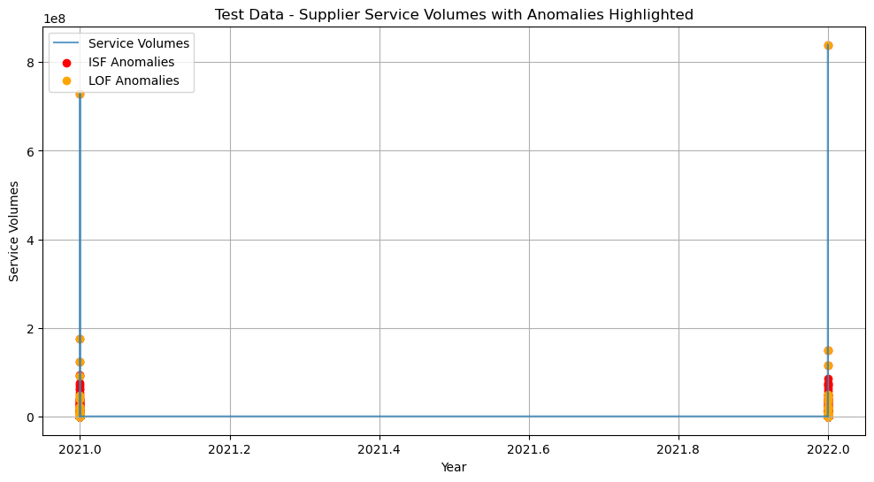

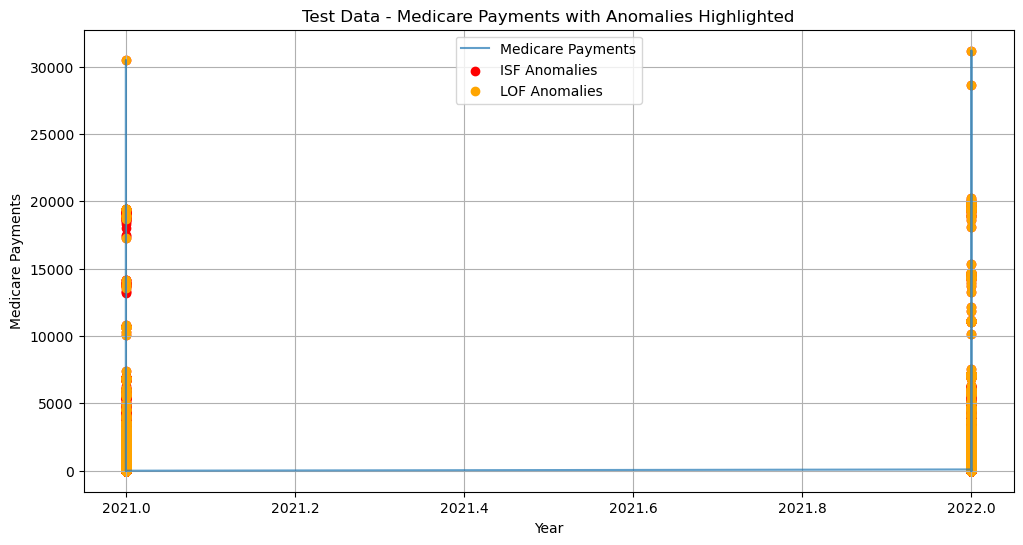

```python
# Load the test data
test_data = pd.read_csv('test_data.csv')

# Define features for scaling and anomaly detection
features = [
    'Tot_Suplrs', 'Tot_Suplr_Benes', 'Tot_Suplr_Srvcs',
    'Avg_Suplr_Sbmtd_Chrg', 'Avg_Suplr_Mdcr_Alowd_Amt',
    'Avg_Suplr_Mdcr_Pymt_Amt'
]

# Scale the test features using the scaler fitted on training data
X_test = scaler.transform(test_data[features])

# Apply Isolation Forest and LOF to the test data
test_data['ISF_Anomaly'] = isf_model.predict(X_test)  # -1 for anomalies, 1 for normal
test_data['LOF_Anomaly'] = lof_model.predict(X_test)  # -1 for anomalies, 1 for normal

# Calculate outlier rates for test data
test_isf_outlier_rate = (test_data['ISF_Anomaly'] == -1).mean()
test_lof_outlier_rate = (test_data['LOF_Anomaly'] == -1).mean()

# Identify shared anomalies in test data
shared_anomalies_test = test_data[
    (test_data['ISF_Anomaly'] == -1) & (test_data['LOF_Anomaly'] == -1)
]

# Print metrics for test data
print(f"Test Data - Isolation Forest Outlier Rate: {test_isf_outlier_rate}")
print(f"Test Data - LOF Outlier Rate: {test_lof_outlier_rate}")
print(f"Test Data - Shared Anomalies: {len(shared_anomalies_test)}")

# Ensure 'Year' column exists for visualization
if 'Year' not in test_data.columns:
    raise ValueError("The 'Year' column is missing from the test dataset.")

# Visualize anomalies in test data for key variables
# Service Volumes
plt.figure(figsize=(12, 6))
plt.plot(test_data['Year'], test_data['Tot_Suplr_Srvcs'], label='Service Volumes', alpha=0.7)
plt.scatter(test_data.loc[test_data['ISF_Anomaly'] == -1, 'Year'],
            test_data.loc[test_data['ISF_Anomaly'] == -1, 'Tot_Suplr_Srvcs'],
            color='red', label='ISF Anomalies')
plt.scatter(test_data.loc[test_data['LOF_Anomaly'] == -1, 'Year'],
            test_data.loc[test_data['LOF_Anomaly'] == -1, 'Tot_Suplr_Srvcs'],
            color='orange', label='LOF Anomalies')
plt.title('Test Data - Supplier Service Volumes with Anomalies Highlighted')
plt.xlabel('Year')
plt.ylabel('Service Volumes')
plt.legend()
plt.grid(True)
plt.show()

# Medicare Payments
plt.figure(figsize=(12, 6))
plt.plot(test_data['Year'], test_data['Avg_Suplr_Mdcr_Pymt_Amt'], label='Medicare Payments', alpha=0.7)
plt.scatter(test_data.loc[test_data['ISF_Anomaly'] == -1, 'Year'],
            test_data.loc[test_data['ISF_Anomaly'] == -1, 'Avg_Suplr_Mdcr_Pymt_Amt'],
            color='red', label='ISF Anomalies')
plt.scatter(test_data.loc[test_data['LOF_Anomaly'] == -1, 'Year'],
            test_data.loc[test_data['LOF_Anomaly'] == -1, 'Avg_Suplr_Mdcr_Pymt_Amt'],
            color='orange', label='LOF Anomalies')
plt.title('Test Data - Medicare Payments with Anomalies Highlighted')
plt.xlabel('Year')
plt.ylabel('Medicare Payments')
plt.legend()
plt.grid(True)
plt.show()
```

## Model Comparison on Test Data

The table below summarizes the results of anomaly detection on the test data using Isolation Forest (ISF) and Local Outlier Factor (LOF):

| Metric | ISF | LOF |
| --- | --- | --- |
| Outlier Rate (Test Data) | 0.0555 | 0.0730 |
| Shared Anomalies | 1196 |  |

### Observations:

1. **Consistency**:
   - ISF shows consistent performance between training and test data, with an outlier rate almost identical to its training average (**0.0555 vs. 0.055**).
   - LOF detects slightly more anomalies on the test data compared to its training average (**0.0730 vs. 0.069**), indicating higher sensitivity.
1. **Sensitivity**:
   - LOF tends to flag more anomalies, potentially detecting subtler patterns but also risking over-detection (false positives).
1. **Shared Anomalies**:
   - A significant number of anomalies (**1196**) are detected by both models, showing agreement and robust anomaly detection.

### Conclusion:

- **Isolation Forest (ISF)** is preferable for its stability and generalization across training and test datasets.
- **Local Outlier Factor (LOF)** may be better for uncovering subtler anomalies but requires careful tuning to avoid false positives.

### Temporal Analysis of Supplier Service Volumes and Medicare Payments with Anomalies

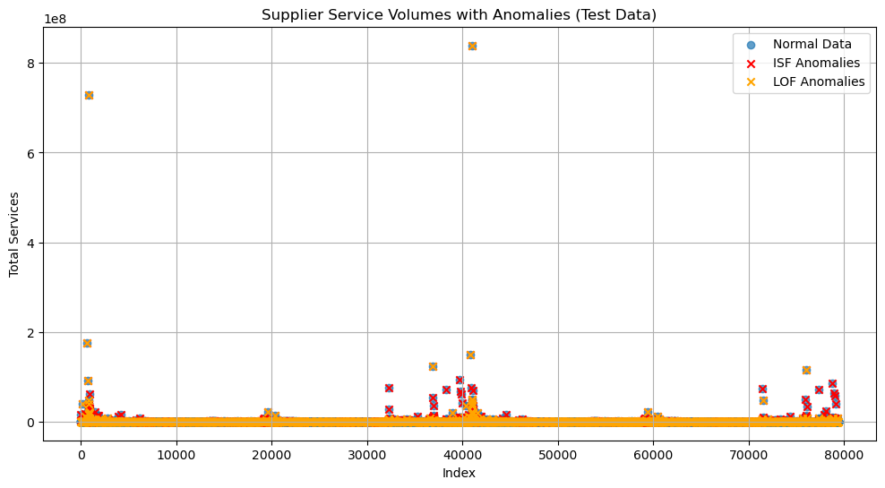

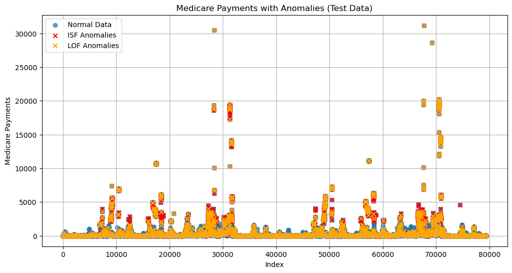

```python
# Scatter plot for anomalies in service volumes
plt.figure(figsize=(12, 6))
plt.scatter(test_data.index, test_data['Tot_Suplr_Srvcs'], label="Normal Data", alpha=0.7)
plt.scatter(test_data[test_data['ISF_Anomaly'] == -1].index, test_data[test_data['ISF_Anomaly'] == -1]['Tot_Suplr_Srvcs'], color="red", label="ISF Anomalies", marker="x")
plt.scatter(test_data[test_data['LOF_Anomaly'] == -1].index, test_data[test_data['LOF_Anomaly'] == -1]['Tot_Suplr_Srvcs'], color="orange", label="LOF Anomalies", marker="x")
plt.title("Supplier Service Volumes with Anomalies (Test Data)")
plt.xlabel("Index")
plt.ylabel("Total Services")
plt.legend()
plt.grid(True)
plt.show()

# Scatter plot for anomalies in Medicare payments
plt.figure(figsize=(12, 6))
plt.scatter(test_data.index, test_data['Avg_Suplr_Mdcr_Pymt_Amt'], label="Normal Data", alpha=0.7)
plt.scatter(test_data[test_data['ISF_Anomaly'] == -1].index, test_data[test_data['ISF_Anomaly'] == -1]['Avg_Suplr_Mdcr_Pymt_Amt'], color="red", label="ISF Anomalies", marker="x")
plt.scatter(test_data[test_data['LOF_Anomaly'] == -1].index, test_data[test_data['LOF_Anomaly'] == -1]['Avg_Suplr_Mdcr_Pymt_Amt'], color="orange", label="LOF Anomalies", marker="x")
plt.title("Medicare Payments with Anomalies (Test Data)")
plt.xlabel("Index")
plt.ylabel("Medicare Payments")
plt.legend()
plt.grid(True)
plt.show()
```

### Analysis of Supplier Service Volumes and Medicare Payments (Test Data)

#### Supplier Service Volumes (Top Plot)

- **Anomaly Patterns**:
  - ISF anomalies (red crosses) and LOF anomalies (orange crosses) are clustered in specific regions.
  - High anomaly density observed in later indices indicates potential irregularities or extreme behavior in service volumes.
- **Normal Data**:
  - Majority of the data (blue points) align closely with consistent service volume levels, highlighting stable supplier activity.

#### Medicare Payments (Bottom Plot)

- **Anomaly Observations**:
  - Similar to service volumes, ISF and LOF anomalies appear in distinct clusters, often indicating unusual Medicare payment values.
  - ISF and LOF anomalies largely overlap but also capture unique patterns, suggesting complementary detection capabilities.
- **Normal Data**:
  - Medicare payments for normal data points (blue) show consistent patterns with fewer outliers.

#### **Complementary Methods**:

- ISF and LOF together provide a robust mechanism to capture anomalies, with overlapping results reinforcing reliability and unique anomalies offering additional insights.

## Analysis of Shared Anomalies in Test Data by Year and Region

## Shared Anomalies in Test Data

```python
# Identify shared anomalies in the test data
shared_anomalies = test_data[
    (test_data['ISF_Anomaly'] == -1) & (test_data['LOF_Anomaly'] == -1)
]

print(f"Total Shared Anomalies in Test Data: {len(shared_anomalies)}")
```

```
Total Shared Anomalies in Test Data: 1196
```

### Analyze Shared Anomalies by Year

```python
# Analyze shared anomalies by year
shared_anomalies_by_year = shared_anomalies['Year'].value_counts().sort_index()
print("Shared Anomalies by Year:")
print(shared_anomalies_by_year)
```

```
Shared Anomalies by Year:
Year
2021    439
2022    757
Name: count, dtype: int64
```

### Analyze Shared Anomalies by Region

```python
# Analyze shared anomalies by region
shared_anomalies_by_region = shared_anomalies.groupby("Rfrg_Prvdr_Geo_Desc")[["Tot_Suplr_Srvcs", "Avg_Suplr_Mdcr_Pymt_Amt"]].sum()
print("Shared Anomalies by Region:")
print(shared_anomalies_by_region)
```

```
Shared Anomalies by Region:
                      Tot_Suplr_Srvcs  Avg_Suplr_Mdcr_Pymt_Amt
Rfrg_Prvdr_Geo_Desc
Alabama                      17576756            105322.900244
Alaska                             93             20902.138909
Arizona                      34113867             86163.226005
Arkansas                         2097            101546.618156
California                   67475453            229594.811907
Colorado                      6691563            126944.570733
Connecticut                      1027             93083.238362
Delaware                         1159             81859.506250
District of Columbia              317             25555.296895
Florida                     104173873            221610.975799
Georgia                      39368490             99584.591354
Hawaii                            122             41479.572318
Idaho                        11851557             32521.494749
Illinois                     90249492            117812.519024
Indiana                      36565433            148513.808450
Iowa                         17496281             89961.633722
Kansas                       36315522             89509.695684
Kentucky                     39128452            138747.421561
Louisiana                        2492            114897.911553
Maine                             280             80757.834959
Maryland                       135533             88039.534436
Massachusetts                17731504             96948.796100
Michigan                     39511139            118677.320642
Minnesota                      148879            125153.644510
Mississippi                  20624173            107121.274862
Missouri                     38470141            136111.436635
Montana                           221             51852.204410
National                   2635052121            596827.411974
Nebraska                          837             86052.984764
Nevada                           5013             81815.034018
New Hampshire                     355             55254.109086
New Jersey                    2012812            116648.614142
New Mexico                        283             33343.832802
New York                     21598331            137519.452044
North Carolina                   5925            120325.749968
North Dakota                  6846054             28478.774520
Ohio                         19145394             96017.307075
Oklahoma                     37803603            100324.415112
Oregon                            883            100263.524194
Pennsylvania                 17550338            137596.303394
Puerto Rico                        41             10248.842581
Rhode Island                      202             20820.594047
South Carolina                 103121            110304.399489
South Dakota                      123             24288.370308
Tennessee                    17276303            112533.185574
Texas                         1687209            178122.790395
Utah                          6764907            110703.489917
Vermont                            67             22070.971036
Virginia                       124458             84316.252448
Washington                      89199            118034.025617
West Virginia                    1436             53493.974458
Wisconsin                      263188             97414.777850
Wyoming                           257             53918.009827
```

### Removing Anomalies from the Dataset Using Isolation Forest

```python
# Flag anomalies using Isolation Forest
train_data['ISF_Anomaly'] = isf_model.predict(X_train)  # -1 for anomalies, 1 for normal
cleaned_data = train_data[train_data['ISF_Anomaly'] == 1]  # Keep only normal data points

# Print results
print(f"Original dataset size: {len(train_data)}")
print(f"Cleaned dataset size: {len(cleaned_data)}")
print(f"Anomalies removed: {len(train_data) - len(cleaned_data)}")
```

```
Original dataset size: 295052
Cleaned dataset size: 280299
Anomalies removed: 14753
```

## Temporal Analysis of Supplier Service Volumes and Medicare Payments

```
Yearly Aggregated Data:
      Tot_Suplr_Srvcs  Avg_Suplr_Mdcr_Pymt_Amt
Year
2014       3249997591             1.068471e+07
2015       3180048899             1.083066e+07
2016       3263646302             1.078826e+07
2017       3301066474             1.082177e+07
2018       3321776498             1.116771e+07
2019       3712041166             1.163357e+07
2020       4484908040             1.178683e+07
2021       4427725684             1.146666e+07
2022       4465939081             1.176085e+07
```

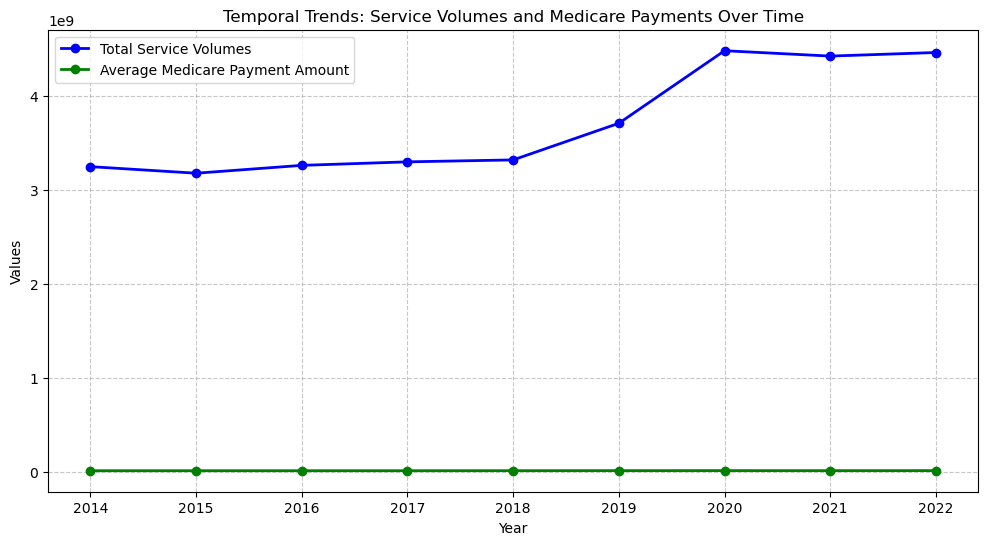

```python
# Combine training and test data
full_data = pd.concat([train_data, test_data], axis=0)

# Aggregate data by year for temporal trend analysis
yearly_data = full_data.groupby("Year")[["Tot_Suplr_Srvcs", "Avg_Suplr_Mdcr_Pymt_Amt"]].sum()

# Display the aggregated yearly data
print("Yearly Aggregated Data:")
print(yearly_data)

# Plot trends over time
plt.figure(figsize=(12, 6))
plt.plot(yearly_data.index, yearly_data["Tot_Suplr_Srvcs"], label="Total Service Volumes", marker='o', color='blue', linewidth=2)
plt.plot(yearly_data.index, yearly_data["Avg_Suplr_Mdcr_Pymt_Amt"], label="Average Medicare Payment Amount", marker='o', color='green', linewidth=2)
plt.title("Temporal Trends: Service Volumes and Medicare Payments Over Time")
plt.xlabel("Year")
plt.ylabel("Values")
plt.legend()
plt.grid(True, linestyle='--', alpha=0.7)
plt.show()
```

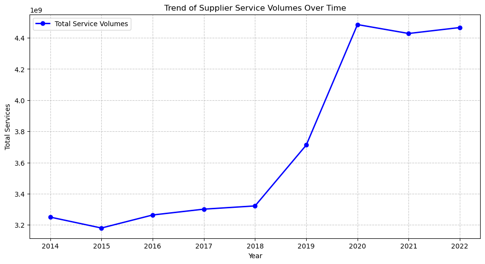

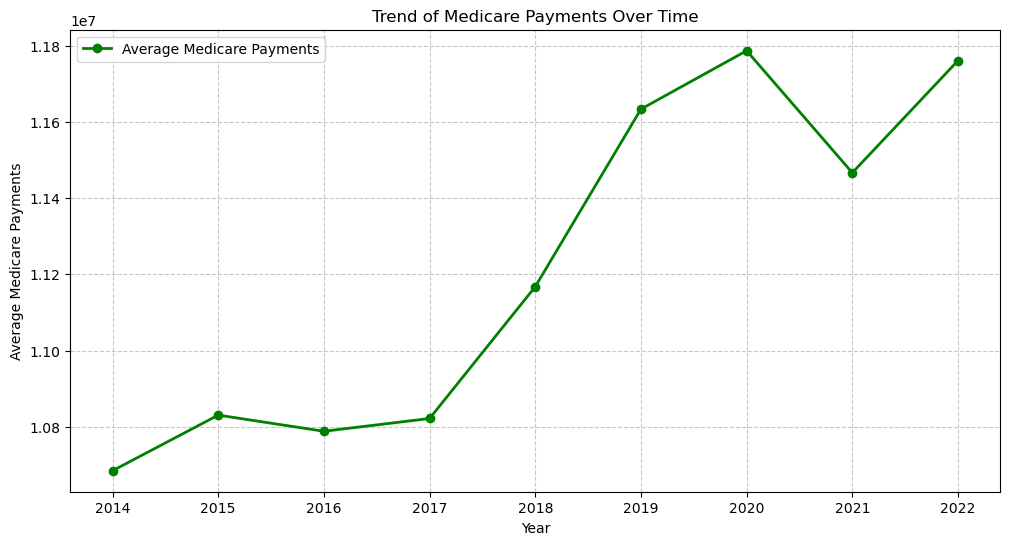

```python
# Plot trends for service volumes
plt.figure(figsize=(12, 6))
plt.plot(yearly_data.index, yearly_data["Tot_Suplr_Srvcs"], marker="o", color="blue", linewidth=2, label="Total Service Volumes")
plt.title("Trend of Supplier Service Volumes Over Time")
plt.xlabel("Year")
plt.ylabel("Total Services")
plt.grid(True, linestyle='--', alpha=0.7)
plt.legend()
plt.show()

# Plot trends for Medicare payments
plt.figure(figsize=(12, 6))
plt.plot(yearly_data.index, yearly_data["Avg_Suplr_Mdcr_Pymt_Amt"], marker="o", color="green", linewidth=2, label="Average Medicare Payments")
plt.title("Trend of Medicare Payments Over Time")
plt.xlabel("Year")
plt.ylabel("Average Medicare Payments")
plt.grid(True, linestyle='--', alpha=0.7)
plt.legend()
plt.show()
```

### Temporal Analysis of Supplier Service Volumes and Medicare Payments

#### Alignment Between Graphs:

- The isolated trends for **Service Volumes** and **Medicare Payments** in the second and third graphs align well with their respective lines in the combined graph.
- Both trends indicate a shift around 2018, marking a period of increased activity and payments.